# Medicaid Expansion and Mental Health

Caz VanDevere

October 18, 2022

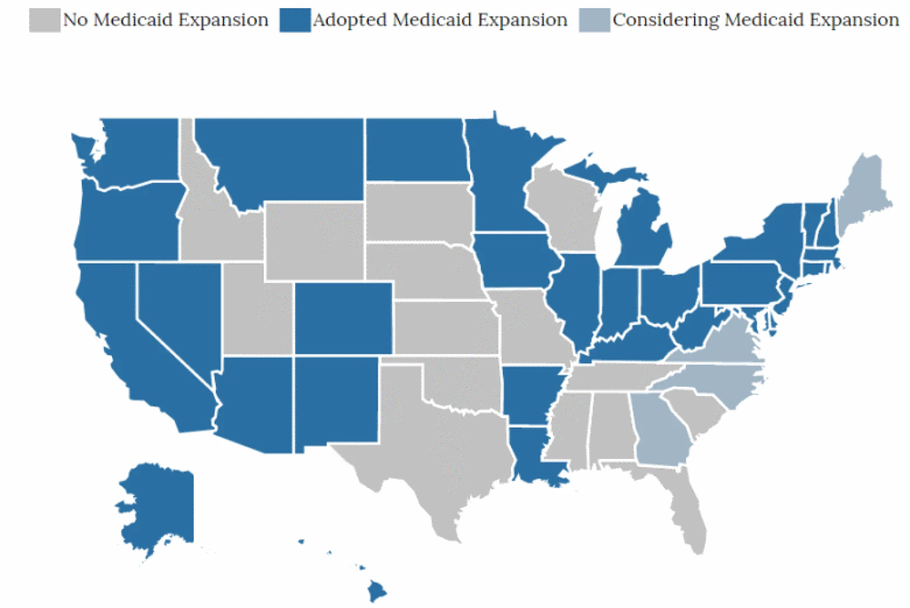

[^1]

## Executive Summary

The health and economic effects of Medicaid expansion under the Affordable Care Act has been studied from various approaches. This report seeks to add to the body of analysis by discussing the effect of expansion on the mental health of people in states where coverage was expanded. A modest positive effect was revealed.

## Introduction

This report will analyze the effect of Medicaid expansion under the Affordable Care Act on mental health outcomes for adult individuals in the United States. The Affordable Care Act, passed in 2010, changed the eligibility requirements for Medicaid, expanding coverage in states that elected to not reject expansion. As of October 2018, Idaho, Nebraska, Utah, Alabama, Florida, Georgia, Kansas, Mississippi, Missouri, North Carolina, Oklahoma, South Carolina, South Dakota, Tennessee, Texas, Wisconsin, and Wyoming have not expanded Medicaid: all other states have expanded coverage.[^2] This report will use a the assumption of parallel trends in difference-in-difference quasi-experimental model to compare the mental health variables in states that expanded Medicaid coverage under the ACA against those that did not.

## Goals of the Affordable Care Act

The Affordable Care Act (ACA) law has three primary goals: make affordable health insurance available to more people, expand the Medicaid program, and support innovative medical care delivery methods designed to lower cost.4 Research has demonstrated progress towards these goals: Medicaid expansion states have had significant coverage gains, increased access to and affordability of care, increased financial security among low-income populations, and improved self-reported health outcomes.5 Less research, however, seems to have been conducted to determine mental health outcomes following the expansion of coverage. Based on evidence from four expansion states in 2014 (Iowa, New York, Washington, and West Virginia), between 20% and 34% of new Medicaid enrollees utilized behavioral health treatment services of drugs.6 This report attempts to determined a more nuanced analysis of mental health outcomes rather than treatments related to expansion.

## The Ideal Mental Health Experiment

An ideal experiment conducted to determine the effects of Medicaid expansion on mental health would be complex and expansive. This analysis controls for sex, education level, and income bracket, as well as state of residence and year fixed effects. Further variable resolution, such as disaggregated mental health variables and continuous income variables, would add strength and clarity to the analysis.

Disaggregated mental health variables, such as those found in the IPUMS Health Surveys, would allow for a more nuanced picture of the exact nature of different effects. Categories of mental health, such as anxiety; depression; stress; and social and emotional support may clarify which types of mental health Medicaid coverage affects. Further category breakdowns, such as worry about medical costs, standards of living, paying rent/mortgage, children’s college, panic attacks, eating disorders, depression caused by the death of a loved one, intensity of depressive feelings, and treatments for any mental health symptoms would add useful and potentially actionable detail to the results.

Additionally, controlling for income as a potential confounding variable would improve the strength of the analysis. Income may have an effect on mental health, and preliminary research demonstrates that a large share of new Medicaid enrollees are in a low-income bracket.7 Income in the BRFSS dataset is coded categorically, in levels of less than $10,000, $10,000 to less than $15,000, $15,000 to less than $20,000, $20,000 to less than $25,000, $25,000 to less than $35,000, $35,000 to less than $50,000, $50,000 to less than $75,000, and $75,000 or more. A continuously coded income variable would allow for analyzing specific Medicaid eligibility cut-offs, poverty rates, and inflation adjustments.

## Data Source and Key Variable Measurement

The report will utilize Behavioral Risk Factor Surveillance System survey data from 2000 until 2017, the date of the most recent survey. Given that the ACA was passed in 2010, this allows for ten years of trend data before the Act, and seven years of data after the Act was passed. One specific variable pertaining to mental health symptoms (‘menthlth’, renamed ‘mental’ for this analysis) will be compared against Medicaid coverage before and after the implementation of the ACA. Menthlth data is surveyed as follows: “Now thinking about your mental health, which includes stress, depression, and problems with emotions, for how many days during the past 30 days was your mental health not good?” The variable is coded by ‘number of days’, ‘none’, ‘don’t know/not sure’, ‘refused’, or missing. ‘Don’t know/not sure’, ‘refused’, or missing results were dropped before conducting the analysis.

This report recognizes that quantifying mental health might be difficult, and there may exist a spectrum of diagnosed and undiagnosed conditions. For example, individuals may have differing thresholds for what constitutes a ‘not good mental health day;’ answers may be disingenuous due to societal pressure and stigma; and feelings of depression, stress, or problems with emotions may represent fundamentally different causal indicators. This report suggests, in lieu of more specific and disaggregated variables, that menthlth demonstrate general trends in mental health.

## Identification Strategy and Assumptions

States have widely varying demographic parameters. In order to generate common support and increase the strength of the analysis, this report used propensity score matching to determine a group of common support states. The healthcare coverage rate, employment rate, high school graduate rate, and college graduate rate in the year 2000 were used to predict whether or not a state would expand Medicaid by 2017. The predicted value was used to remove states that were very likely to expand coverage and those that were very unlikely to expand coverage. States above 93% and below 35% were removed from common support. The cut-off probabilities were determined via an examination of the distribution: clear outliers were present below and above the expected values. Arizona, Connecticut, Washington DC, Kentucky, Massachusetts, Mississippi, Tennessee, and Washington were dropped from the common support. Mississippi and Tennessee were the only two states that did not expand Medicaid to be dropped from the model.

## Conclusion

[^1]: Kaiser Family Foundation. State Medicaid Expansion Map. April 10, 2017. http://www.governing.com/gov-data/health/state-medicaid-expansion-adoption-status-map.html
[^2]: Kaiser Family Foundation. Status of State Action on the Medicaid Expansion Decision. November 26, 2018. https://www.kff.org/health-reform/state-indicator/state-activity-around-expanding-medicaid-under-the-affordable-care-act/?currentTimeframe=0&sortModel=%7B%22colId%22:%22Location%22,%22sort%22:%22asc%22%7D